# Prática curso de Data Science

Primeira prática R… módulo 09

```r
setwd("~/Estudos/CursoDados/todos os arquivos/9.Pr tica em R/")
dados = read.csv("../../todos os arquivos/9.Pr tica em R/dados/Churn.csv",sep = ";",na.strings = "",stringsAsFactors = T)
head(dados)
```

|  | X0 | X1 | X2 | X3 | X4 | X4.1 | X6 | X7 | X8 | X9 | X10 | X11 |
| --- | --- | --- | --- | --- | --- | --- | --- | --- | --- | --- | --- | --- |
| 1 | 1 | 619 | RS | Feminino | 42 | 2 | 0 | 1 | 1 | 1 | 10134888 | 1 |
| 2 | 2 | 608 | SC | Feminino | 41 | 1 | 8380786 | 1 | 0 | 1 | 11254258 | 0 |
| 3 | 3 | 502 | RS | Feminino | 42 | 8 | 1596608 | 3 | 1 | 0 | 11393157 | 1 |
| 4 | 4 | 699 | RS | Feminino | 39 | 1 | 0 | 2 | 0 | 0 | 9382663 | 0 |
| 5 | 5 | 850 | SC | Feminino | 43 | 2 | 12551082 | 1 | 1 | 1 | 790841 | 0 |
| 6 | 6 | 645 | SC | Masculino | 44 | 8 | 11375578 | 2 | 1 | 0 | 14975671 | 1 |

```r
summary(dados)
```

```
       X0               X1         X2              X3            X4
 Min.   :   1.0   Min.   :376.0   PR:257   F        :  2   Min.   :-20.0
 1st Qu.: 251.5   1st Qu.:580.0   RP:  1   Fem      :  1   1st Qu.: 32.0
 Median : 501.0   Median :653.0   RS:478   Feminino :461   Median : 37.0
 Mean   : 500.9   Mean   :648.6   SC:258   M        :  6   Mean   : 38.9
 3rd Qu.: 750.5   3rd Qu.:721.0   SP:  4   Masculino:521   3rd Qu.: 44.0
 Max.   :1000.0   Max.   :850.0   TD:  1   NA's     :  8   Max.   :140.0

      X4.1              X6                 X7              X8
 Min.   : 0.000   Min.   :       0   Min.   :1.000   Min.   :0.0000
 1st Qu.: 2.000   1st Qu.:       0   1st Qu.:1.000   1st Qu.:0.0000
 Median : 5.000   Median : 8958835   Median :1.000   Median :1.0000
 Mean   : 5.069   Mean   : 7164928   Mean   :1.527   Mean   :0.7027
 3rd Qu.: 8.000   3rd Qu.:12586844   3rd Qu.:2.000   3rd Qu.:1.0000
 Max.   :10.000   Max.   :21177431   Max.   :4.000   Max.   :1.0000

       X9              X10                 X11
 Min.   :0.0000   Min.   :9.677e+03   Min.   :0.0000
 1st Qu.:0.0000   1st Qu.:3.029e+06   1st Qu.:0.0000
 Median :1.0000   Median :8.703e+06   Median :0.0000
 Mean   :0.5095   Mean   :3.529e+07   Mean   :0.2032
 3rd Qu.:1.0000   3rd Qu.:1.405e+07   3rd Qu.:0.0000
 Max.   :1.0000   Max.   :1.193e+10   Max.   :1.0000
                  NA's   :7
```

```r
colnames(dados) = c("Id","Score","Estado","Genero","Idade","Patrimonio","Saldo","Produtos","TemCartCredito","Ativo","Salario","Saiu")
```

```r
counts = table(dados$Estado)
counts
```

```
 PR  RP  RS  SC  SP  TD
257   1 478 258   4   1
```

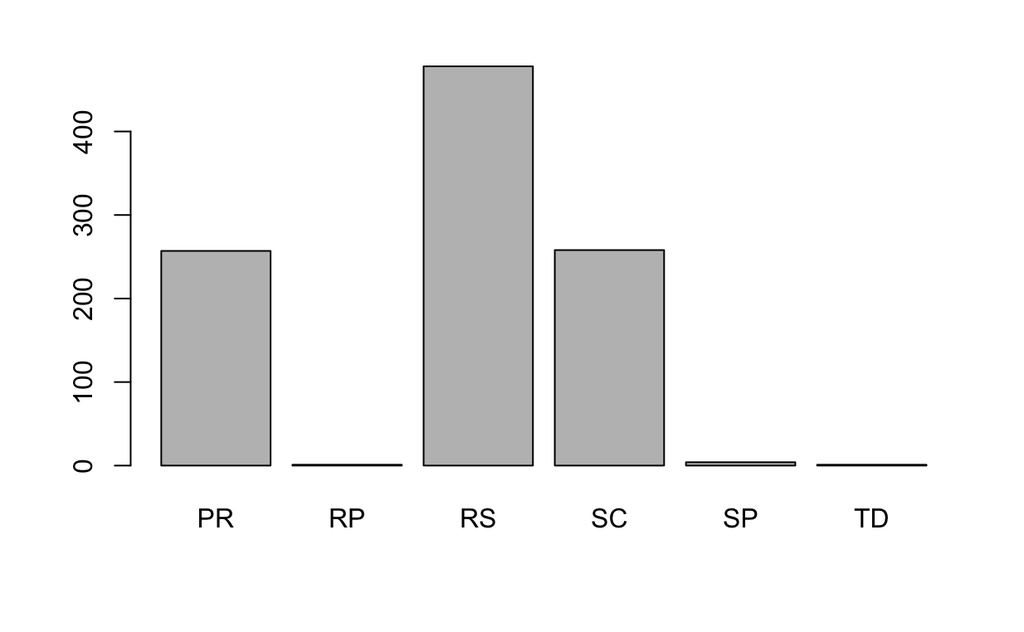

```r
barplot(counts)
```

```r
counts = table(dados$Genero)
counts
```

```
        F       Fem  Feminino         M Masculino
        2         1       461         6       521
```

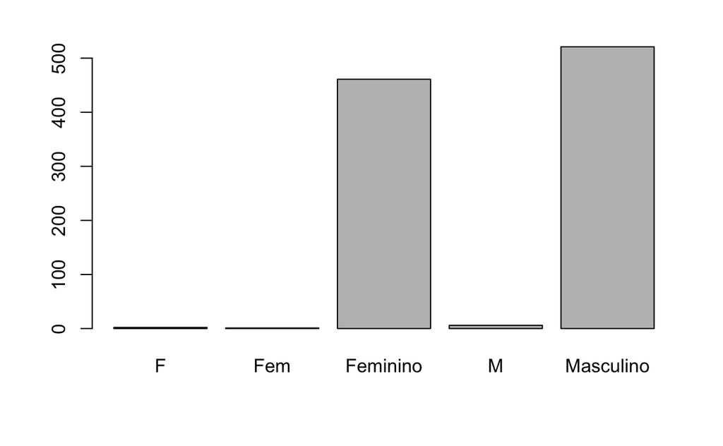

```r
barplot(counts)
```

```r
dados[!complete.cases(dados),]
```

|  | Id | Score | Estado | Genero | Idade | Patrimonio | Saldo | Produtos | TemCartCredito | Ativo | Salario | Saiu |
| --- | --- | --- | --- | --- | --- | --- | --- | --- | --- | --- | --- | --- |
| 18 | 18 | 549 | SC | Feminino | 24 | 9 | 0 | 2 | 1 | 1 | NA | 0 |
| 53 | 53 | 788 | RS | Feminino | 33 | 5 | 0 | 2 | 0 | 0 | NA | 0 |
| 65 | 65 | 603 | PR | NA | 26 | 4 | 10916637 | 1 | 1 | 1 | 9284067 | 0 |
| 85 | 86 | 493 | RS | NA | 46 | 4 | 0 | 2 | 1 | 0 | 190766 | 0 |
| 180 | 181 | 754 | PR | Feminino | 55 | 3 | 16160881 | 1 | 1 | 0 | NA | 1 |
| 214 | 215 | 676 | RS | NA | 34 | 1 | 6309501 | 1 | 1 | 1 | 4064581 | 0 |
| 297 | 298 | 714 | RS | NA | 31 | 4 | 12516926 | 1 | 1 | 1 | 10663689 | 0 |
| 331 | 332 | 656 | RS | Masculino | 50 | 7 | 0 | 2 | 0 | 1 | NA | 0 |
| 371 | 372 | 801 | SC | NA | 42 | 4 | 14194767 | 1 | 1 | 1 | 1059829 | 0 |
| 427 | 428 | 492 | PR | Masculino | 39 | 10 | 12457665 | 2 | 1 | 0 | NA | 0 |

[output cut: 5 more lines]

Tratar os Salários vamos colocar a mediana no lugar dos NA

```r
summary(dados$Salario)
median(dados$Salario,na.rm=T)
m = median(dados$Salario,na.rm=T)
dados$Salario[is.na(dados$Salario)] = m
summary(dados$Salario)
```

Tratar a coluna Genero transformar NA em masculino porque Masculino é a moda (o valor que mais ocorre)

```r
unique(dados$Genero)

dados[is.na(dados$Genero) | dados$Genero == "M",]$Genero = "Masculino"
dados$Genero[dados$Genero == "Fem" | dados$Genero == "F"] = "Feminino"
summary(dados$Genero)
#remover os niveis de dados
dados$Genero =  factor(dados$Genero)
summary(dados$Genero)
```

Idades fora de dominio

```r
summary(dados$Idade)

dados$Idade[dados$Idade<0 | dados$Idade > 110]
# nao há NA
#vamos preencher pela mediana
dados$Idade[dados$Idade<0 | dados$Idade > 110] = median(dados$Idade)
dados$Idade[dados$Idade<0 | dados$Idade > 110]
summary(dados$Idade)
```

Buscar dados duplicados

```r
x=dados[duplicated(dados$Id),]
x
dados[dados$Id %in% x$Id,]
dados = dados[!(dados$Id %in% x$Id),]
dados[duplicated(dados$Id),]
```

Limpar o estado

```r
summary(dados$Estado)
#RS é o estado que mais aparece
dados$Estado[!(dados$Estado %in% c("SC","RS","PR"))] = "RS"
summary(dados$Estado)
dados$Estado = factor(dados$Estado)
```

REMOVER OUTLIERS Padronizar que o salario nao pode ser maior que 2x o desvio padrao do salario

```r
summary(dados$Salario)
desvio = sd(dados$Salario, na.rm = T)
desvio

dados$Salario[dados$Salario>2*desvio | is.na(dados$Salario)] = median(dados$Salario,na.rm = T)
summary(dados$Salario)
```

FAÇA você mesmo!!!!

```r
dados = read.csv("../../todos os arquivos/9.Pr tica em R/dados/tempo.csv",sep = ";",na.strings = "",stringsAsFactors = T)
head(dados)
dados[!complete.cases(dados),]

summary(dados)

summary(dados$Aparencia)
dados$Aparencia[!(dados$Aparencia %in% c("chuva","sol","nublado")) | is.na(dados$Aparencia)] = "chuva"
dados$Aparencia = factor(dados$Aparencia)

dados$Temperatura[dados$Temperatura<(-130) | dados$Temperatura > 130 | is.na(dados$Temperatura)] = median(dados$Temperatura, na.rm=T)
summary(dados$Temperatura)

summary(dados$Umidade)
dados$Umidade[dados$Umidade<0 | dados$Umidade>100 | is.na(dados$Umidade)] = median(dados$Umidade,na.rm = T)
summary(dados$Umidade)

summary(dados$Jogar)

summary(dados$Vento)
dados$Vento[is.na(dados$Vento)] = "FALSO"

dados[!complete.cases(dados),]
```

Qui-quadrado: testa se existe diferença significativa entre duas proporções H0: não há diferença significativa p>0.05 -> não rejeita H0

```r
Xsq
```

```
    Pearson's Chi-squared test with Yates' continuity correction

data:  M
X-squared = 1.6674, df = 1, p-value = 0.1966
```

t-student: compara duas médias H0: Não há diferença entre médias p>0.05 -> não rejeita a hipótese nula

| Cientistas tem salario de 75 por hora. Se uma amostra com 9 cientistas tem desvio padrao s = 10, qual a probabilidade de um cientista ganhar menos de 80 |
| --- |

```r
pt(1.5,8)
```

```
[1] 0.9139984
```

ANOVA: teste entre 3 ou mais grupos H0: não há diferença entre os grupos p>0.05 -> não rejeita a hipótese nula

Se há variação - > testar os pares com o teste de Turkey

Métricas de Erro

- Mean Error
- Mean Absolute Error
- Mean Squared Error
- Mean percentage error
- Mean Absolute percentage error

Correlação -> qual é a relação (linear) entre duas variáveis -> R

Coeficiente de Determinação -> mostra o quanto o modelo explica os valores -> R^2

- Para criar um modelo linear, espera-se que a correlação seja moderada ou forte
- Espera-se que os resíduos tenham distribuição normal

  * Diagrama de normalidade QQnorm

- Pra regressão linear multipla: variancia dos resíduos constante na linha de melhor ajuste

```r
library(corrgram)
cars
cor(cars)
corrgram(cars,lower.panel = panel.shade,upper.panel = panel.pie)
```

Modelo de regressão

```r
modelo.regressao = lm(speed~dist,data = cars)
modelo.regressao
```

```
Call:
lm(formula = speed ~ dist, data = cars)

Coefficients:
(Intercept)         dist
     8.2839       0.1656
```

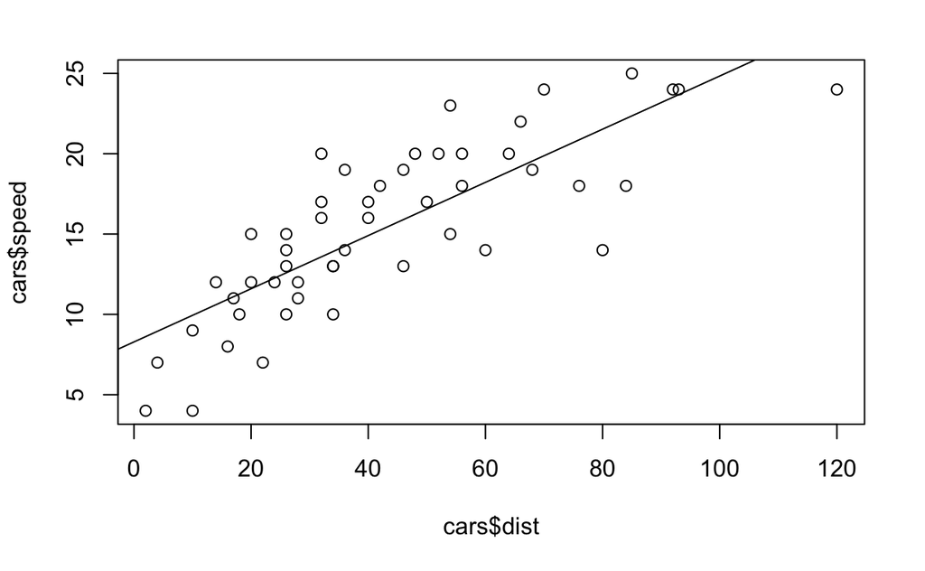

```r
plot(cars$dist,cars$speed)
abline(modelo.regressao)
```

Para fazer previsao

```r
dados = data.frame(dist = 20)
predict(modelo.regressao,dados)
```

Algumas funções e informações

```r
summary(modelo.regressao)
modelo.regressao$residuals
hist(modelo.regressao$residuals)
```

Regressão logística: Resposta binária: SIM ou NÃO

```r
eleicoes = read.csv("~/Estudos/CursoDados/todos os arquivos/24.Pr tica em R/dados/Eleicao.csv",sep = ";")
head(eleicoes)
```

|  | CANDIDATO | SITUACAO | DESPESAS |
| --- | --- | --- | --- |
| 1 | George Turner | 0 | 10 |
| 2 | Victor Johnson | 0 | 100 |
| 3 | Jerry Perry | 1 | 1600 |
| 4 | Shirley Cook | 1 | 1500 |
| 5 | Carolyn Bailey | 1 | 3300 |
| 6 | Susan Sanders | 0 | 200 |

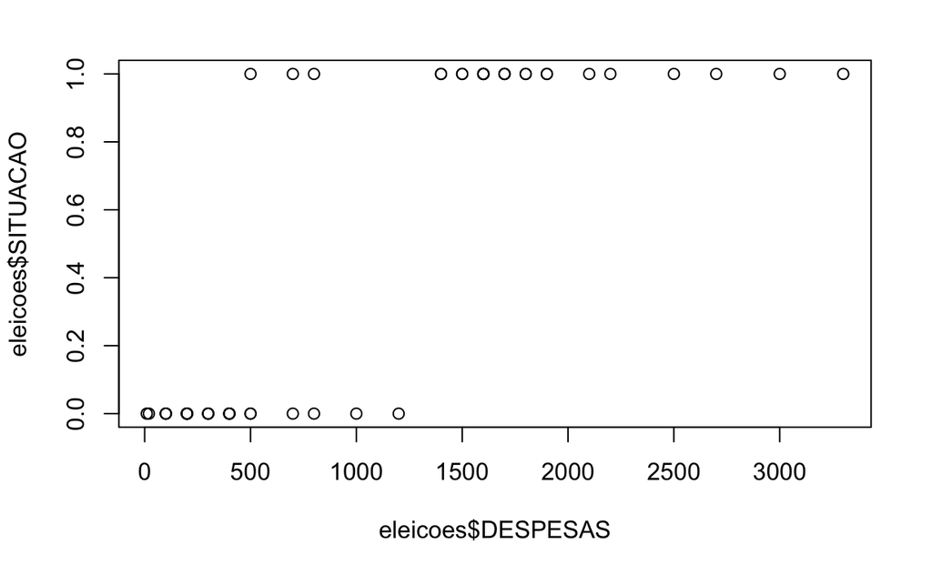

```r
plot(eleicoes$DESPESAS,eleicoes$SITUACAO)
```

```r
cor(eleicoes$SITUACAO,eleicoes$DESPESAS)
```

```
[1] 0.8121872
```

Fazer a regressão logística modelo linear generalizado familia binomial

```r
summary(modelo)
```

```
Call:
glm(formula = SITUACAO ~ DESPESAS, family = "binomial", data = eleicoes)

Deviance Residuals:
     Min        1Q    Median        3Q       Max
-1.79020  -0.29574   0.00379   0.20326   2.10968

Coefficients:
             Estimate Std. Error z value Pr(>|z|)
(Intercept) -4.602880   1.315934  -3.498 0.000469 ***
DESPESAS     0.004984   0.001404   3.550 0.000385 ***
---
Signif. codes:  0 ‘***’ 0.001 ‘**’ 0.01 ‘*’ 0.05 ‘.’ 0.1 ‘ ’ 1

(Dispersion parameter for binomial family taken to be 1)

    Null deviance: 65.135  on 46  degrees of freedom
Residual deviance: 18.540  on 45  degrees of freedom
AIC: 22.54

Number of Fisher Scoring iterations: 7
```

Gerar o plot

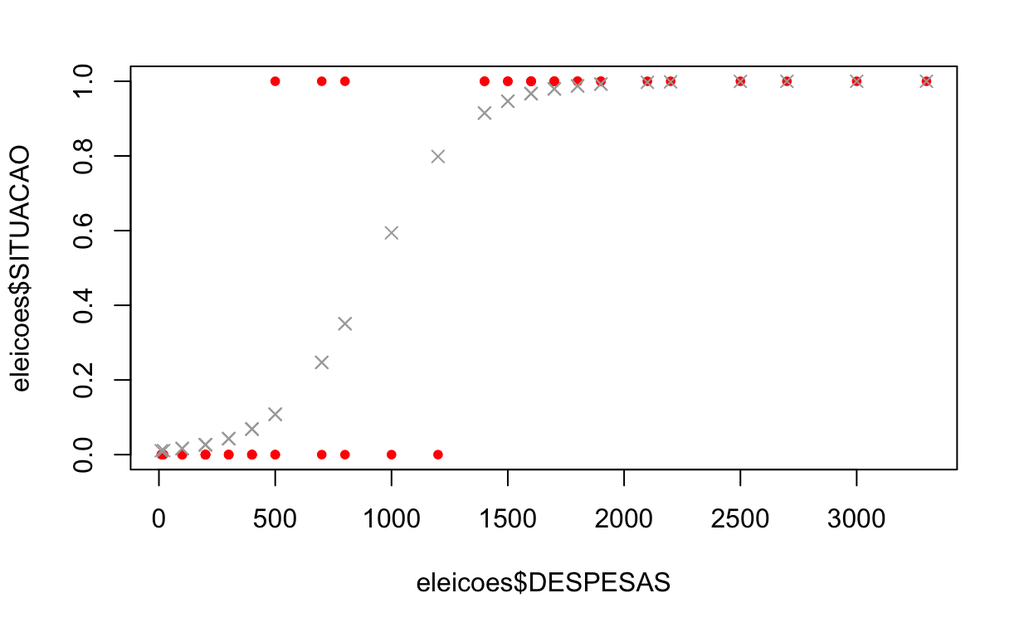

```r
plot(eleicoes$DESPESAS,eleicoes$SITUACAO, pch = 20, col = "red")
points(eleicoes$DESPESAS, modelo$fitted.values, pch = 4, col = "darkgrey")
```

Testar o modelo com os próprios candidatos

```r
predito = predict(modelo,newdata = eleicoes,type = "response")
predito
prever = predito >= 0.5
eleicoes$previsto = prever
head(eleicoes)
```

Criar uma matriz de confusão entre o previsto e o status quo

```r
confusao = table(prever,eleicoes$SITUACAO)
confusao
acerto = (confusao[1]+confusao[4])/sum(confusao) #porcentagem de acerto que esta na diagonal
acerto
```

Agora usando novos candidatos

```r
novos = read.csv("~/Estudos/CursoDados/todos os arquivos/24.Pr tica em R/dados/NovosCandidatos.csv", sep = ";")
novos
resultados = predict(modelo, newdata = novos, type = "response")
resultados
previsto = resultados >= 0.5
novos$previsto = previsto
novos
```

Séries Temporais

- Intervalos de tempos iguais
- Podem ser: -Estacionárias (media e variancia “constante”) -Não estacionária -Deterministica ou estocástica

Componentes da série temporal: - Tendência - Sazonalidade - Estocasticidade

Fazer a decomposição da série

ARIMA - precisa de dados estacionarios - os metodos podem transformar os dados em estacionarios

pdq - parametross

metricas - AIC, AICc, BIC

auto.arima() - testa varias combinações